# IST 5535 HW6: German Credit Data

Sayantan Majumdar

2020-03-02

### 1. The data file “credit-g.csv” contains a German credit dataset. The dataset contains 1000 observations (customers) of 21 variables. The response variable is “class”. Read in the dataset and explore it. How many customers in the dataset have good credit?

```r
library(dplyr)
credit.data <- read.csv('credit-g.csv')
glimpse(credit.data)
```

```
## Observations: 1,000
## Variables: 21
## $ checking_status        <fct> <0, 0<=X<200, 'no checking', <0, <0, 'no check…
## $ duration               <int> 6, 48, 12, 42, 24, 36, 24, 36, 12, 30, 12, 48,…
## $ credit_history         <fct> 'critical/other existing credit', 'existing pa…
## $ purpose                <fct> radio/tv, radio/tv, education, furniture/equip…
## $ credit_amount          <int> 1169, 5951, 2096, 7882, 4870, 9055, 2835, 6948…
## $ savings_status         <fct> 'no known savings', <100, <100, <100, <100, 'n…
## $ employment             <fct> >=7, 1<=X<4, 4<=X<7, 4<=X<7, 1<=X<4, 1<=X<4, >…
## $ installment_commitment <int> 4, 2, 2, 2, 3, 2, 3, 2, 2, 4, 3, 3, 1, 4, 2, 4…
## $ personal_status        <fct> 'male single', 'female div/dep/mar', 'male sin…
## $ other_parties          <fct> none, none, none, guarantor, none, none, none,…
## $ residence_since        <int> 4, 2, 3, 4, 4, 4, 4, 2, 4, 2, 1, 4, 1, 4, 4, 2…
## $ property_magnitude     <fct> 'real estate', 'real estate', 'real estate', '…
## $ age                    <int> 67, 22, 49, 45, 53, 35, 53, 35, 61, 28, 25, 24…
## $ other_payment_plans    <fct> none, none, none, none, none, none, none, none…
## $ housing                <fct> own, own, own, 'for free', 'for free', 'for fr…
## $ existing_credits       <int> 2, 1, 1, 1, 2, 1, 1, 1, 1, 2, 1, 1, 1, 2, 1, 1…
## $ job                    <fct> skilled, skilled, 'unskilled resident', skille…
## $ num_dependents         <int> 1, 1, 2, 2, 2, 2, 1, 1, 1, 1, 1, 1, 1, 1, 1, 1…
## $ own_telephone          <fct> yes, none, none, none, none, yes, none, yes, n…
## $ foreign_worker         <fct> yes, yes, yes, yes, yes, yes, yes, yes, yes, y…
## $ class                  <fct> good, bad, good, good, bad, good, good, good, …
```

```r
summary(credit.data)
```

```
##       checking_status    duration                             credit_history
##  'no checking':394    Min.   : 4.0   'all paid'                      : 49
##  <0           :274    1st Qu.:12.0   'critical/other existing credit':293
##  >=200        : 63    Median :18.0   'delayed previously'            : 88
##  0<=X<200     :269    Mean   :20.9   'existing paid'                 :530
##                       3rd Qu.:24.0   'no credits/all paid'           : 40
##                       Max.   :72.0
##
##                 purpose    credit_amount              savings_status
##  radio/tv           :280   Min.   :  250   'no known savings':183
##  'new car'          :234   1st Qu.: 1366   <100              :603
##  furniture/equipment:181   Median : 2320   >=1000            : 48
##  'used car'         :103   Mean   : 3271   100<=X<500        :103
##  business           : 97   3rd Qu.: 3972   500<=X<1000       : 63
##  education          : 50   Max.   :18424
##  (Other)            : 55
##       employment  installment_commitment             personal_status
##  <1        :172   Min.   :1.000          'female div/dep/mar':310
##  >=7       :253   1st Qu.:2.000          'male div/sep'      : 50
##  1<=X<4    :339   Median :3.000          'male mar/wid'      : 92
##  4<=X<7    :174   Mean   :2.973          'male single'       :548
##  unemployed: 62   3rd Qu.:4.000
##                   Max.   :4.000
##
##         other_parties residence_since           property_magnitude
##  'co applicant': 41   Min.   :1.000   'life insurance'   :232
##  guarantor     : 52   1st Qu.:2.000   'no known property':154
##  none          :907   Median :3.000   'real estate'      :282
##                       Mean   :2.845   car                :332
##                       3rd Qu.:4.000
##                       Max.   :4.000
##
##       age        other_payment_plans       housing    existing_credits
##  Min.   :19.00   bank  :139          'for free':108   Min.   :1.000
##  1st Qu.:27.00   none  :814          own       :713   1st Qu.:1.000
##  Median :33.00   stores: 47          rent      :179   Median :1.000
##  Mean   :35.55                                        Mean   :1.407
##  3rd Qu.:42.00                                        3rd Qu.:2.000
##  Max.   :75.00                                        Max.   :4.000
##
##                           job      num_dependents  own_telephone foreign_worker
##  'high qualif/self emp/mgmt':148   Min.   :1.000   none:596      no : 37
##  'unemp/unskilled non res'  : 22   1st Qu.:1.000   yes :404      yes:963
##  'unskilled resident'       :200   Median :1.000
##  skilled                    :630   Mean   :1.155
##                                    3rd Qu.:1.000
##                                    Max.   :2.000
##
##   class
##  bad :300
##  good:700
##
##
##
##
##
```

### 2. Use ggplot2 package to draw a barchart of ‘credit_history’ grouped by ‘class’. The barchart should satisfy below criteria: - The number of customers under each credit history category should be grouped by class - Has a main title “Distribution of Credit History Grouped by Class” - Has x axis labeled as “Credit History” - Has y axis labeled as “Number of Customers”. Explain what insights you can get from the plot regarding predicting customer credit class.

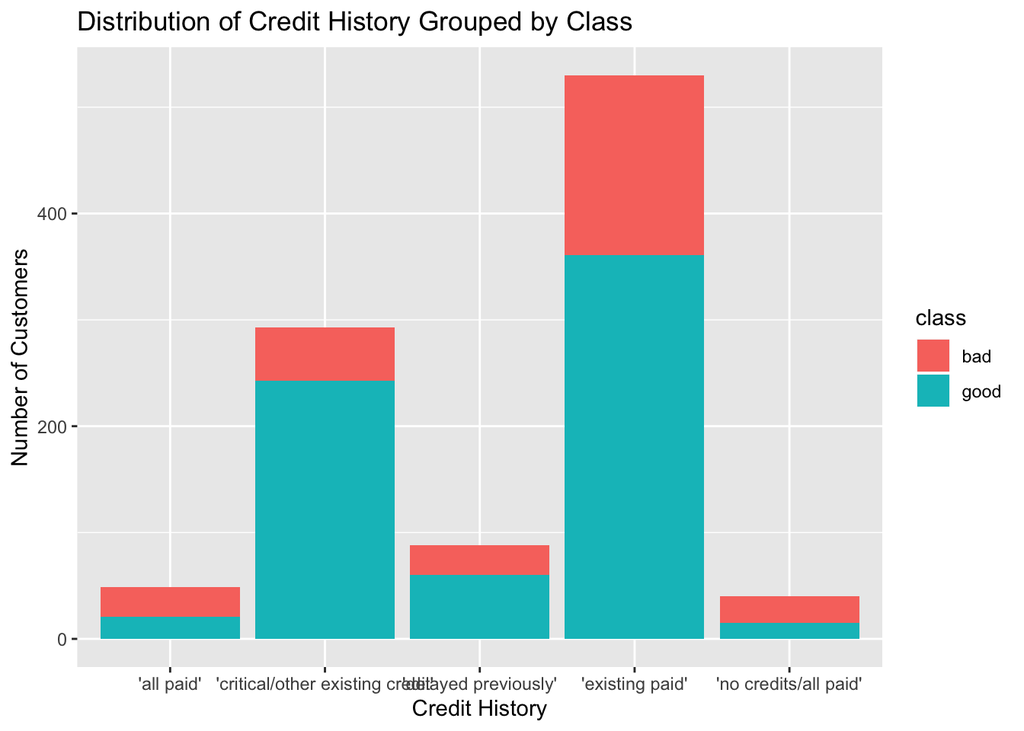

```r
library(ggplot2)

ggplot(data = credit.data, aes(x = credit_history, fill = class)) +
  geom_bar() +
  labs(y = 'Number of Customers', x = 'Credit History', title = 'Distribution of Credit History Grouped by Class')
```

The ‘existing paid’ class has both high ‘bad’ and ‘good’ credit histories.

### 3. Use ggplot2 package to draw a boxplot of ‘credit_amount’ grouped by ‘class’. Explain what insights you can get from the plot regarding predicting customer credit class.

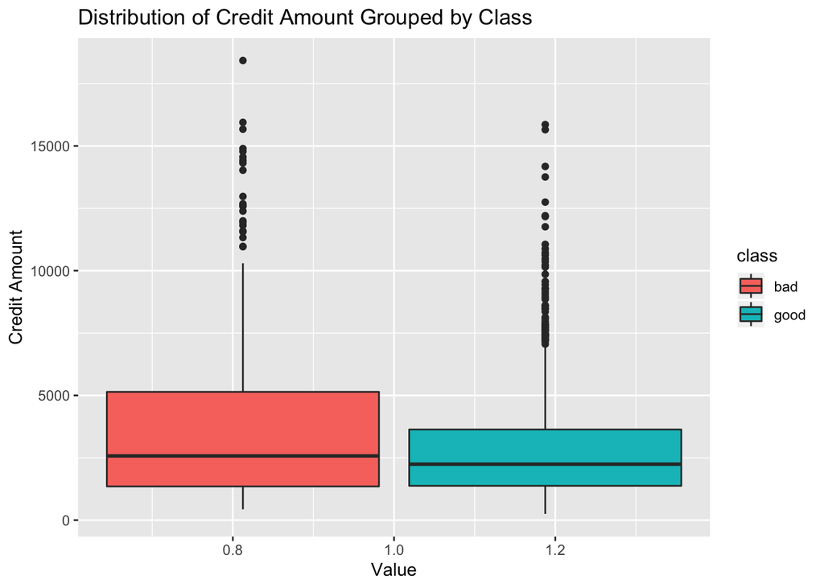

```r
ggplot(data = credit.data, aes(x = 1, y = credit_amount, fill = class)) +
  geom_boxplot() +
  labs(y = 'Credit Amount', x = 'Value', title = 'Distribution of Credit Amount Grouped by Class')
```

The credit amount of ‘bad’ credit users are larger (for all quantiles and median) than that of ‘good’ users. Also, the number of outliers for ‘bad’ credit users is less.

### 4. Randomly split the whole dataset as two parts: training set containing 80% of the data, and test set containing 20% of the data.

```r
library(caret)
set.seed(0)
partition <- createDataPartition(as.factor(credit.data$class), p = 0.8, list = F)
credit.data.train <- credit.data[partition,]
credit.data.test <- credit.data[-partition,]
```

### 5. Conduct a logistic regression to predict bad credit customers in the training set, using all other variables as predictors. Treat “bad” as the positive class and “good” as negative class. That is, the following model specification is used: logit(class=‘bad’|X) = $\beta_0 + \beta_1X_1 + \beta_2X_2 + ... + \beta_pX_p$

```r
logit.fit <- glm(class ~ ., family = binomial(link='logit'), data = credit.data.train)

summary(logit.fit)
```

```
##
## Call:
## glm(formula = class ~ ., family = binomial(link = "logit"), data = credit.data.train)
##
## Deviance Residuals:
##     Min       1Q   Median       3Q      Max
## -2.7034  -0.7292   0.3768   0.7127   2.0726
##
## Coefficients:
##                                                  Estimate Std. Error z value
## (Intercept)                                     4.892e+00  1.660e+00   2.947
## checking_status<0                              -1.696e+00  2.619e-01  -6.475
## checking_status>=200                           -7.813e-01  4.185e-01  -1.867
## checking_status0<=X<200                        -1.308e+00  2.632e-01  -4.971
## duration                                       -2.382e-02  1.085e-02  -2.195
## credit_history'critical/other existing credit'  1.537e+00  4.855e-01   3.165
## credit_history'delayed previously'              8.129e-01  5.215e-01   1.559
## credit_history'existing paid'                   6.105e-01  4.262e-01   1.432
## credit_history'no credits/all paid'             4.443e-01  6.083e-01   0.730
## purpose'new car'                               -8.461e-01  8.875e-01  -0.953
## purpose'used car'                               8.991e-01  9.581e-01   0.938
## purposebusiness                                -8.499e-02  9.251e-01  -0.092
## purposeeducation                               -7.286e-01  9.490e-01  -0.768
## purposefurniture/equipment                     -2.148e-01  8.982e-01  -0.239
## purposeother                                    1.116e+00  1.266e+00   0.882
## purposeradio/tv                                 6.126e-02  8.846e-01   0.069
## purposerepairs                                 -6.468e-01  1.063e+00  -0.609
## purposeretraining                               1.377e+01  6.299e+02   0.022
## credit_amount                                  -1.484e-04  5.170e-05  -2.871
## savings_status<100                             -1.137e+00  3.060e-01  -3.715
## savings_status>=1000                            3.630e-01  6.356e-01   0.571
## savings_status100<=X<500                       -9.559e-01  4.019e-01  -2.378
## savings_status500<=X<1000                      -5.762e-01  5.225e-01  -1.103
## employment>=7                                   2.241e-01  3.296e-01   0.680
## employment1<=X<4                                2.065e-02  2.699e-01   0.077
## employment4<=X<7                                1.090e+00  3.498e-01   3.117
## employmentunemployed                            3.113e-01  4.817e-01   0.646
## installment_commitment                         -3.474e-01  9.908e-02  -3.506
## personal_status'male div/sep'                   1.755e-01  4.236e-01   0.414
## personal_status'male mar/wid'                  -1.023e-01  3.431e-01  -0.298
```

[output cut: 64 more lines]

```
## job'unskilled resident'                        0.910299
## jobskilled                                     0.939654
## num_dependents                                 0.420299
## own_telephoneyes                               0.201186
## foreign_workeryes                              0.046720 *
## ---
## Signif. codes:  0 '***' 0.001 '**' 0.01 '*' 0.05 '.' 0.1 ' ' 1
##
## (Dispersion parameter for binomial family taken to be 1)
##
##     Null deviance: 977.38  on 799  degrees of freedom
## Residual deviance: 716.82  on 751  degrees of freedom
## AIC: 814.82
##
## Number of Fisher Scoring iterations: 14
```

#### a. Explain variables that have significant positive or negative effects. Do these directions of these effects make sense? Are the logistic regression results consistent with your findings in steps 2 and 3?

Here, all the predictors having p-values < 0.05 or absolute z-value > 2 are significant. Here, we see that ‘critical/other existing credit’ type of credits and ‘credit amount’ are both significant. This finding is consisent with steps 2 and 3.

#### b. Evaluate the performance of the logistic regression on the test set. Calculate overall accuracy, sensitivity, and specificity. Which measure is best to evaluate how the model predicts bad credit customers? Does this logistic regression model do a good job in classifying bad credit customers?

```r
test_probs <- predict(logit.fit, newdata = credit.data.test, type = "response")

# Show the first 10 values
knitr::kable(test_probs[1:10])
```

|  | x |
| --- | --- |
| 10 | 0.2745177 |
| 12 | 0.1522348 |
| 19 | 0.3334663 |
| 23 | 0.8876254 |
| 24 | 0.9525377 |
| 32 | 0.4521328 |
| 35 | 0.4339047 |
| 36 | 0.5014192 |
| 38 | 0.6190881 |
| 50 | 0.7797599 |

```r
test_pred <- ifelse(test_probs >.5, "good", "bad")

# Show confusion matrix
confusionMatrix(factor(test_pred), credit.data.test$class, positive = "bad")
```

```
## Confusion Matrix and Statistics
##
##           Reference
## Prediction bad good
##       bad   27   15
##       good  33  125
##
##                Accuracy : 0.76
##                  95% CI : (0.6947, 0.8174)
##     No Information Rate : 0.7
##     P-Value [Acc > NIR] : 0.03595
##
##                   Kappa : 0.375
##
##  Mcnemar's Test P-Value : 0.01414
##
##             Sensitivity : 0.4500
##             Specificity : 0.8929
##          Pos Pred Value : 0.6429
##          Neg Pred Value : 0.7911
##              Prevalence : 0.3000
##          Detection Rate : 0.1350
##    Detection Prevalence : 0.2100
##       Balanced Accuracy : 0.6714
##
##        'Positive' Class : bad
##
```

```r
sensitivity(factor(test_pred), credit.data.test$class, positive = "bad")
```

```
## [1] 0.45
```

```r
specificity(factor(test_pred), credit.data.test$class, negative = "good")
```

```
## [1] 0.8928571
```

The overall accuracy is 0.76 which is somewhat acceptable. However, we suffer from low sensitivity which means that the model does not do a good job in classifying bad credit customers. On the other hand, the model does very well to identify good credit customers due to the high specificity.

### 6. Perform LDA on the training data in order to predict class using only the variables that are found significantly impacting the credit class in the logistic regression analysis (include the whole categorical variable even some levels are not significant in logistic regression). Calculate overall accuracy, sensitivity, and specificity on the test data. Does the model do a good job in classifying bad credit customers?

```r
predictors <- summary(logit.fit)$coeff[-1,4] < 0.05
predictor.names <- names(predictors)[predictors == T]
predictor.names
```

```
##  [1] "checking_status<0"
##  [2] "checking_status0<=X<200"
##  [3] "duration"
##  [4] "credit_history'critical/other existing credit'"
##  [5] "credit_amount"
##  [6] "savings_status<100"
##  [7] "savings_status100<=X<500"
##  [8] "employment4<=X<7"
##  [9] "installment_commitment"
## [10] "personal_status'male single'"
## [11] "other_partiesguarantor"
## [12] "other_payment_plansnone"
## [13] "foreign_workeryes"
```

```r
library(MASS)
```

```r
lda.fit <- lda(class ~ checking_status + credit_history + credit_amount + savings_status + employment + personal_status + other_parties + other_payment_plans + foreign_worker + installment_commitment, data = credit.data.train)
summary(lda.fit)
```

```
##         Length Class  Mode
## prior    2     -none- numeric
## counts   2     -none- numeric
## means   50     -none- numeric
## scaling 25     -none- numeric
## lev      2     -none- character
## svd      1     -none- numeric
## N        1     -none- numeric
## call     3     -none- call
## terms    3     terms  call
## xlevels  8     -none- list
```

```r
lda.fit$scaling
```

```
##                                                          LD1
## checking_status<0                              -1.5296026550
## checking_status>=200                           -0.4813665122
## checking_status0<=X<200                        -1.0322176530
## credit_history'critical/other existing credit'  1.1857240312
## credit_history'delayed previously'              0.6812302365
## credit_history'existing paid'                   0.6660671844
## credit_history'no credits/all paid'             0.0928238735
## credit_amount                                  -0.0001407029
## savings_status<100                             -0.7423286951
## savings_status>=1000                            0.2152996697
## savings_status100<=X<500                       -0.7684282016
## savings_status500<=X<1000                      -0.2355386792
## employment>=7                                   0.2855865872
## employment1<=X<4                                0.1241003114
## employment4<=X<7                                0.8240224437
## employmentunemployed                            0.5592575858
## personal_status'male div/sep'                   0.1793860908
## personal_status'male mar/wid'                   0.1888308252
## personal_status'male single'                    0.5158518586
## other_partiesguarantor                          1.4789854126
## other_partiesnone                               0.3733968377
## other_payment_plansnone                         0.6001032882
## other_payment_plansstores                       0.2913039371
## foreign_workeryes                              -0.6043883628
## installment_commitment                         -0.2874939445
```

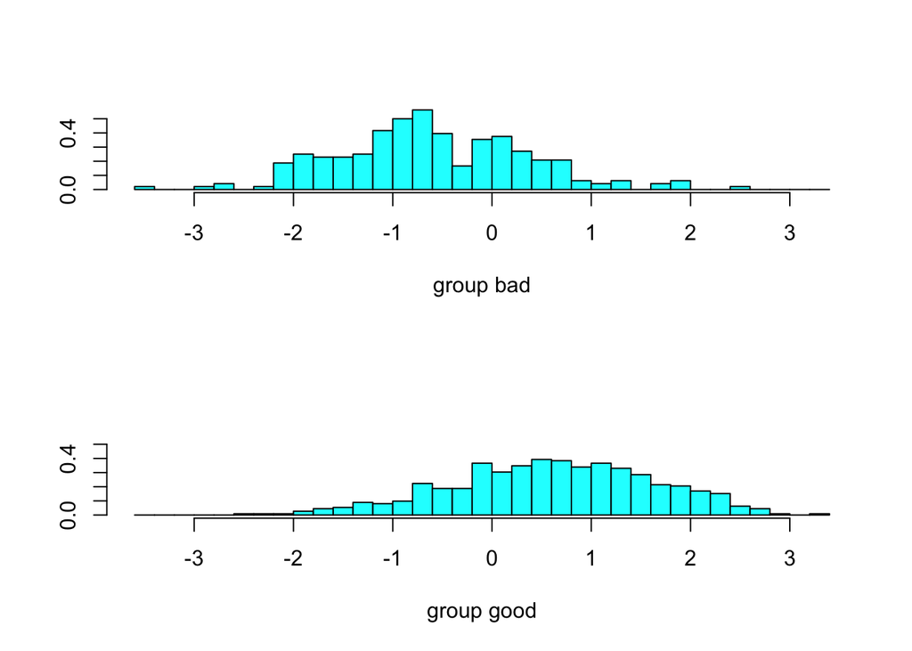

```r
plot(lda.fit)
```

```r
lda.pred <- predict(lda.fit, newdata = credit.data.test)
names(lda.pred)
```

```
## [1] "class"     "posterior" "x"
```

The green points in class 2 (“good”) and red points in class 1 (“bad”) represent the misclassified response.

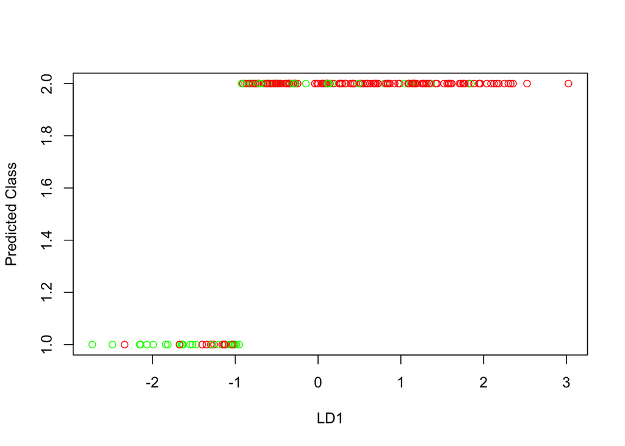

```r
plot(lda.pred$x, lda.pred$class, col = c("green","red")[credit.data.test$class], xlab = 'LD1', ylab = 'Predicted Class')
```

```r
confusionMatrix(factor(lda.pred$class), credit.data.test$class, positive = "bad")
```

```
## Confusion Matrix and Statistics
##
##           Reference
## Prediction bad good
##       bad   25   12
##       good  35  128
##
##                Accuracy : 0.765
##                  95% CI : (0.7, 0.8219)
##     No Information Rate : 0.7
##     P-Value [Acc > NIR] : 0.024933
##
##                   Kappa : 0.3717
##
##  Mcnemar's Test P-Value : 0.001332
##
##             Sensitivity : 0.4167
##             Specificity : 0.9143
##          Pos Pred Value : 0.6757
##          Neg Pred Value : 0.7853
##              Prevalence : 0.3000
##          Detection Rate : 0.1250
##    Detection Prevalence : 0.1850
##       Balanced Accuracy : 0.6655
##
##        'Positive' Class : bad
##
```

Here, we observe that the overall accuracy has slightly increased along with the specificity. However, the sensitivity is decreased. So this model is doing worse than the logistic regression.